# PAC 1 Dades omiques

Balma Albalat Oliver

#INFORME ##1.DESCRIPCIÓ I JUSTIFICACIO DE LA BASE DE DADES ## He triat la database associada al projecte Metabolomics of Psoriasis. ## Aquesta pot consular-se en el repositori “Metabolomics workbench” amb l’identificador de projecte PR000239. ## He triat aquest tema perquè pateixo aquesta malaltia i m’ha causat curiositat #aprofundir en aquesta qüestió. ## Es tracta d’un estudi desenvolupat pel Departament de Dermatologia de la Universitat de Michigan, dirigit per l’investigador Johann Gudjonsson. L’objectiu de l’estudi és estudiar els metabolits esteroides en els teixits de pacients amb diferents estats de psoriasis. Per assolir-lo es van realitzar biòpsis per obtenir 9 mostres de pell que es van categoritzar en 3 subgrups:

#-Pell sana (3) -Pell afectada per psoriasis (3) -Pell no afectada en pacients amb psoriasis (3)

#A través de la cromatografía líquida acoplada a l’espectrometria de masses (LC-MS) es van analitzar les concentracions d’esteroides, expressades en pg/mg de teixit, caracteritzant d’aquesta manera els perfils metabòlics de cada mostra de pell.

```r
##### PREPARACIÓ I IMPORTACIÓ DE LES DADES ####

# Importar l'arxiu de dades '.json'

library(jsonlite)
json_data <-jsonlite::fromJSON("ST000298_AN000476.json", flatten = TRUE)
# Cerquem i resolem valors nuls #
null_values <- sapply(json_data, function(x) any(is.null(x)))
na_values <- sapply(json_data, function(x) any(is.na(x)))
# Print results
print("Valors nuls en:")
```

```
[1] "Valors nuls en:"
```

```r
print(names(json_data)[null_values])
```

```
character(0)
```

```r
### Creació colData (info i factor mostres) ###
# Extraem la info de json_data
if (is.data.frame(json_data$SUBJECT_SAMPLE_FACTORS)) {
  sample_df <- json_data$SUBJECT_SAMPLE_FACTORS
} else {
  sample_info <- as.character(unlist(data$SUBJECT_SAMPLE_FACTORS))
  sample_df <- read.table(text = sample_info, sep = "\t", header = FALSE, stringsAsFactors = FALSE)
}
colnames(sample_df) <- c("Subject", "SampleID", "Factors")

# Associem els factors a columnes i creem colData#

# Crear un DataFrame de factores
factor_df <- data.frame(Factor = sample_df$Factors)

# Combinar con el DataFrame original
colData <- cbind(sample_df[, "SampleID", drop = FALSE], factor_df)

# Asignar nombres a las filas
row.names(colData) <- colData$SampleID

# Ver el resultado
head(colData)
```

|  | SampleID | Factor |
| --- | --- | --- |
| S00017314 | S00017314 | Psoriasis involved |
| S00017315 | S00017315 | Psoriasis involved |
| S00017316 | S00017316 | Psoriasis involved |
| S00017317 | S00017317 | Psoriasis uninvolved |
| S00017318 | S00017318 | Psoriasis uninvolved |
| S00017319 | S00017319 | Psoriasis uninvolved |

```r
### Extreuracció de dades metabòliques (fe) ###
# L'utilitzarem per a fer els anàlisi #

metabolite_data<-json_data$MS_METABOLITE_DATA$Data
metabolite_matrix <- as.data.frame(metabolite_data)
rownames(metabolite_matrix) <- metabolite_matrix$Metabolite
metabolite_matrix <- t(metabolite_matrix)
metabolite_matrix <- as.matrix(sapply(metabolite_matrix, as.numeric))
head(metabolite_matrix)
```

```
                 [,1]
11-deoxycortisol   NA
0.570            0.57
0.610            0.61
0                0.00
0.31             0.31
2.68             2.68
```

```r
metabolite_data <- json_data$MS_METABOLITE_DATA$Data
metabolite_matrix <- as.data.frame(metabolite_data)
rownames(metabolite_matrix) <- metabolite_matrix$Metabolite
metabolite_matrix <- metabolite_matrix[, -1]  # Eliminar la columna redundant
metabolite_matrix[metabolite_matrix == ""] <- NA
metabolite_matrix <- as.matrix(sapply(metabolite_matrix, as.numeric))
head(metabolite_matrix)
```

```
     S00017317 S00017315 S00017322 S00017316 S00017318 S00017319 S00017320 S00017321 S00017314
[1,]      0.57      0.61      0.00      0.31      2.68      0.26      0.93      3.33      1.43
[2,]      1.76      0.48      3.74      0.97      3.05      1.29      5.26      9.88      2.05
[3,]      0.18      6.83     29.85    111.35    109.30     53.91    337.19   2126.34     66.98
[4,]      0.60      4.62      4.86      3.82      7.71      8.01     17.09    105.27      4.02
[5,]      0.57        NA      0.85        NA        NA      0.82        NA        NA      0.63
[6,]      6.10      3.30     23.00     24.10     20.10     21.70    130.80    915.40     26.60
```

2. CREAR OBJECTE ‘SummarizedExperiment’

```r
# Comprovem que coincideixen les files

nrow(metabolite_matrix)
```

```
[1] 9
```

```r
nrow(colData)
```

```
[1] 9
```

```r
# Generm el SummarizedExperiment

library(POMA)
poma_obj <- PomaCreateObject(
  metadata = colData,
  features = metabolite_matrix
)

# Verifiquem

poma_obj
```

```
class: SummarizedExperiment
dim: 9 9
metadata(0):
assays(1): ''
rownames(9): S00017317 S00017315 ... S00017321 S00017314
rowData names(0):
colnames(9): S00017314 S00017315 ... S00017321 S00017322
colData names(1): Factor
```

3. AFEGIM METADADES GENERALS DEL PROJECTE (METADATA)

```r
# Afegim les metadades a l'objecte SummarizedExperiment
for (key in names(json_data$METABOLOMICS)) {
  metadata(poma_obj)$METABOLOMICS[[key]] <- json_data$METABOLOMICS[[key]]
}
for (key in names(json_data$PROJECT)) {
  metadata(poma_obj)$PROJECT[[key]] <- json_data$PROJECT[[key]]
}

for (key in names(json_data$STUDY)) {
  metadata(poma_obj)$STUDY[[key]] <- json_data$STUDY[[key]]
}

for (key in names(json_data$SUBJECT)) {
  metadata(poma_obj)$SUBJECT[[key]] <- json_data$SUBJECT[[key]]
}

for (key in names(json_data$SUBJECT_SAMPLE_FACTORS)) {
  metadata(poma_obj)$SUBJECT_SAMPLE_FACTORS[[key]] <- json_data$SUBJECT_SAMPLE_FACTORS[[key]]
}

for (key in names(json_data$COLLECTION)) {
  metadata(poma_obj)$COLLECTION[[key]] <- json_data$COLLECTION[[key]]
}

for (key in names(json_data$TREATMENT)) {
  metadata(poma_obj)$TREATMENT[[key]] <- json_data$TREATMENT[[key]]
}

for (key in names(json_data$SAMPLEPREP)) {
  metadata(poma_obj)$SAMPLEPREP[[key]] <- json_data$SAMPLEPREP[[key]]
}

for (key in names(json_data$CHROMATOGRAPHY)) {
  metadata(poma_obj)$CHROMATOGRAPHY[[key]] <- json_data$CHROMATOGRAPHY[[key]]
}

for (key in names(json_data$ANALYSIS)) {
  metadata(poma_obj)$ANALYSIS[[key]] <- json_data$ANALYSIS[[key]]
}

for (key in names(json_data$MS)) {
  metadata(poma_obj)$MS[[key]] <- json_data$MS[[key]]
}
for (key in names(json_data$MS_METABOLITE_DATA)) {
  metadata(poma_obj)$MS_METABOLITE_DATA[[key]] <- json_data$MS_METABOLITE_DATA[[key]]
}
metadata(poma_obj)
```

[output not shown]

[output cut: 117 more lines]

[output not shown]

|  | Metabolite | S00017317 | S00017315 | S00017322 | S00017316 | S00017318 | S00017319 | S00017320 | S00017321 | S00017314 |
| --- | --- | --- | --- | --- | --- | --- | --- | --- | --- | --- |
| 1 | 11-deoxycortisol | 0.570 | 0.610 | 0 | 0.31 | 2.68 | 0.26 | 0.93 | 3.33 | 1.43 |
| 2 | 11-DOC | 1.760 | 0.480 | 3.74 | 0.97 | 3.05 | 1.29 | 5.26 | 9.88 | 2.05 |
| 3 | 17-Hydroxyprogesterone | 0.180 | 6.830 | 29.85 | 111.35 | 109.3 | 53.91 | 337.19 | 2126.34 | 66.98 |
| 4 | Androstenedione | 0.600 | 4.620 | 4.86 | 3.82 | 7.71 | 8.01 | 17.09 | 105.27 | 4.02 |
| 5 | Corticosterone | 0.570 |  | 0.85 |  |  | 0.82 |  |  | 0.63 |
| 6 | Cortisol | 6.1 | 3.3 | 23 | 24.1 | 20.1 | 21.7 | 130.8 | 915.4 | 26.6 |
| 7 | Cortisone | 8.9 | 2.8 | 6 | 11 | 14.3 | 8.4 | 5.1 | 16.6 | 6.2 |
| 8 | Progesterone | 7.130 | 2.040 | 9.29 | 7.15 | 32.09 | 8.36 | 82.13 | 136.38 | 11.35 |
| 9 | Testosterone | 0.540 | 0.300 | 1.1 | 0.71 | 1.59 | 0.29 | 2.59 | 2.41 | 0.46 |

```
$MS_METABOLITE_DATA$Metabolites
```

|  | Metabolite | PubChem CID |
| --- | --- | --- |
| 1 | 11-deoxycortisol | 440707 |
| 2 | 11-DOC | 6166 |
| 3 | 17-Hydroxyprogesterone | 6238 |
| 4 | Androstenedione | 6128 |
| 5 | Corticosterone | 5753 |
| 6 | Cortisol | 5754 |
| 7 | Cortisone | 222786 |
| 8 | Progesterone | 5994 |
| 9 | Testosterone | 6013 |

```
NANA
```

4. REVISEM LA INFO DE L’OBJECTE

```r
sample_df <- json_data$SUBJECT_SAMPLE_FACTORS
colnames(sample_df) <- c("Subject", "SampleID", "Factors")

colData <- data.frame(
  Factor = sample_df$Factors,
  row.names = sample_df$SampleID
)

metabolite_data <- json_data$MS_METABOLITE_DATA$Data
rownames(metabolite_data) <- metabolite_data$Metabolite
metabolite_data <- metabolite_data[, -1]

assay_matrix <- as.matrix(metabolite_data)
mode(assay_matrix) <- "numeric"
assay_matrix <- assay_matrix[, rownames(colData), drop = FALSE]

poma_obj <- SummarizedExperiment(
  assays = list(counts = assay_matrix),
  colData = colData
)

poma_obj <- PomaImpute(poma_obj, method = "knn", zeros_as_na = TRUE, remove_na = TRUE, cutoff = 20)
```

```
1 features removed.
```

```r
sum(is.na(assay(poma_obj)))
```

```
[1] 0
```

5. ANÀLISI EXPLORATORI

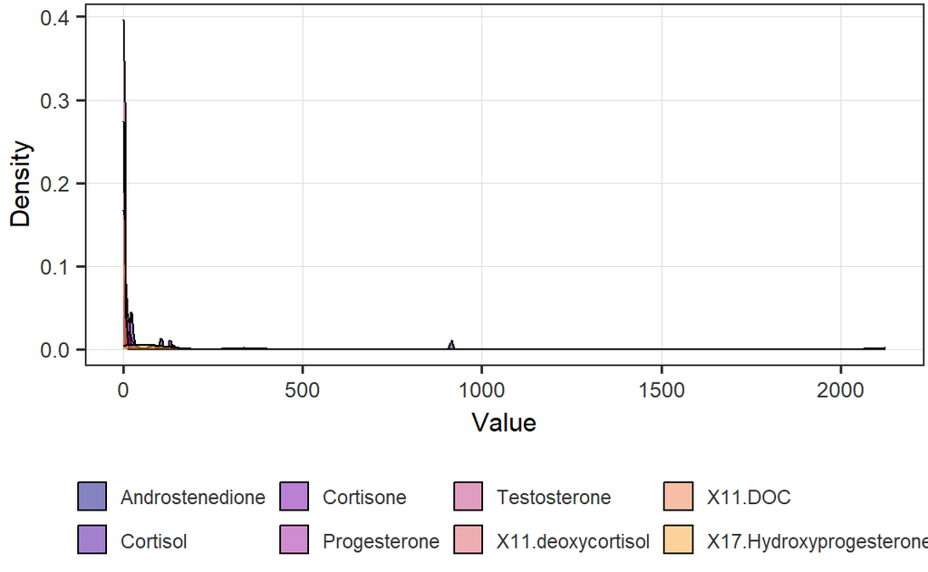

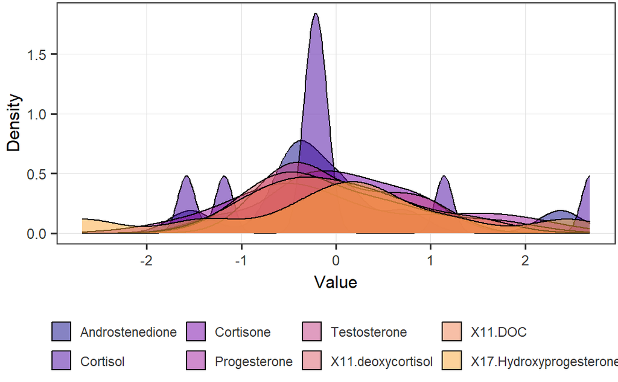